# Dirichlet regression and the 2018 Quebec Elections (with brms)

### Renting

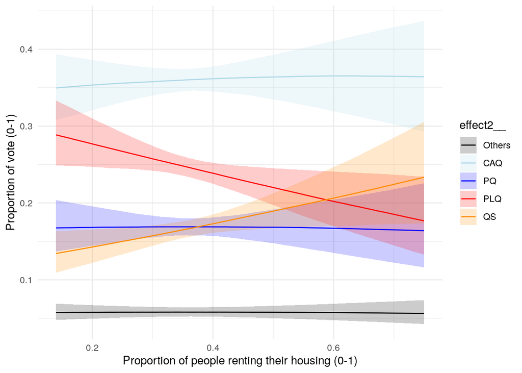

```r
p <- plot(marginal_effects(fit, categorical = T, effects = "loc_pourc"),
                      plot = F)

p$`loc_pourc:cats__`$data %>%
  ggplot(aes(x = effect1__)) +
  geom_ribbon(aes(ymin = lower__, ymax = upper__, fill = effect2__), alpha = 0.2) +
  geom_line(aes(y = estimate__, color = effect2__)) +
  theme_minimal() +
  xlab("Proportion of people renting their housing (0-1)") +
  ylab("Proportion of vote (0-1)") +
  scale_color_manual(values = c("black", "light blue", "blue", "red", "dark orange")) +
  scale_fill_manual(values = c("black", "light blue", "blue", "red", "dark orange"))
```

QS tended to be favored in the division with more people renting their housing, while PLQ was less popular in such divisions.

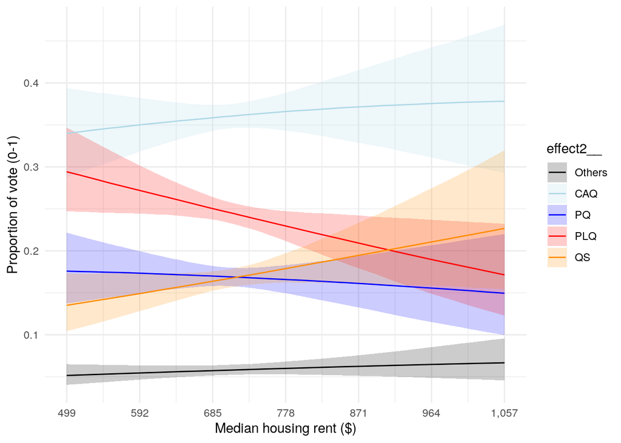

```r
p <- plot(marginal_effects(fit, categorical = T, effects = "n_cout_hab_loc_pourc"),
                      plot = F)

## Denormalize the x-axis
library(scales)
minval <- min(X$cout_hab_loc_pourc)
maxval <- max(X$cout_hab_loc_pourc)

norm_trans <- function(minval, maxval){
  require(scales)
  normalize <- function(x){
    top <- (b-a) * (x - min(x, na.rm = T))
    bot <- max(x, na.rm = T) - min(x, na.rm = T)
    y <- top/bot
    }
  denormalize <- function(xt) {xt*(maxval-minval) + minval}
  trans_new("normalize", transform = normalize, inverse = denormalize)
}

p$`n_cout_hab_loc_pourc:cats__`$data %>%
  ggplot(aes(x = effect1__)) +
  geom_ribbon(aes(ymin = lower__, ymax = upper__, fill = effect2__), alpha = 0.2) +
  geom_line(aes(y = estimate__, color = effect2__)) +
  theme_minimal() +
  xlab("Median housing rent ($)") +
  ylab("Proportion of vote (0-1)") +
  scale_x_continuous(trans = norm_trans(minval, maxval), labels = comma) +
  scale_color_manual(values = c("black", "light blue", "blue", "red", "dark orange")) +
  scale_fill_manual(values = c("black", "light blue", "blue", "red", "dark orange"))
```

Similarly, the higher the rent was, the more people voted for QS, and the less they voted for PLQ.

### Estate value

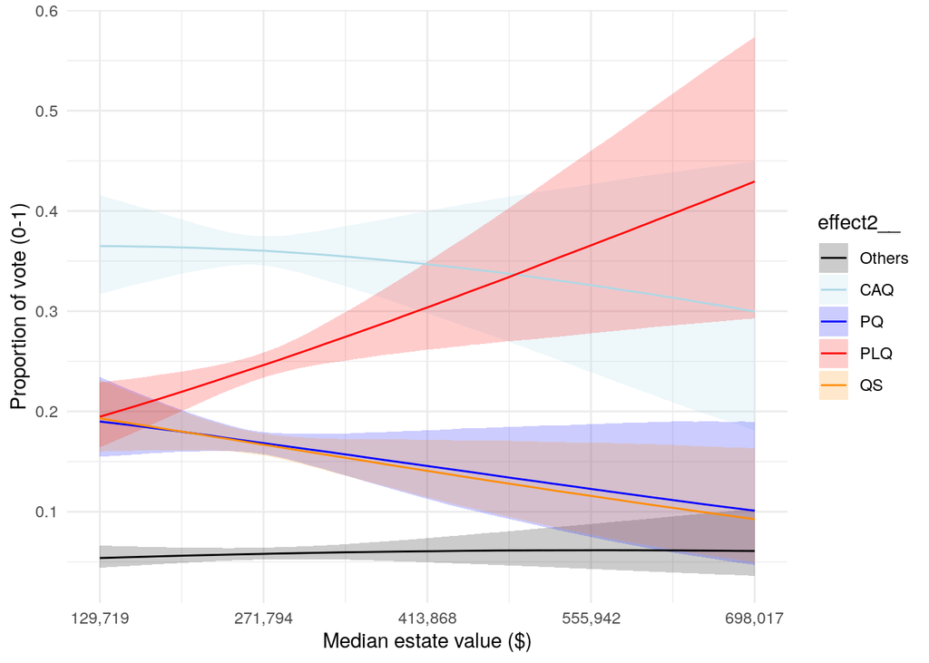

```r
## Denormalize the x-axis
minval <- min(X$valeur_logement_mediane)
maxval <- max(X$valeur_logement_mediane)
p <- plot(marginal_effects(fit, categorical = T, effects = "n_valeur_logement_mediane"),
                      plot = F)

p$`n_valeur_logement_mediane:cats__`$data %>%
  ggplot(aes(x = effect1__)) +
  geom_ribbon(aes(ymin = lower__, ymax = upper__, fill = effect2__), alpha = 0.2) +
  geom_line(aes(y = estimate__, color = effect2__)) +
  theme_minimal() +
  xlab("Median estate value ($)") +
  ylab("Proportion of vote (0-1)") +
  scale_x_continuous(trans = norm_trans(minval, maxval), labels = comma) +
  scale_color_manual(values = c("black", "light blue", "blue", "red", "dark orange")) +
  scale_fill_manual(values = c("black", "light blue", "blue", "red", "dark orange"))
```

# Conclusion

We first show that dirichlet regression is an efficient and relatively simple solution to analyse compositional data. Concrete and simple functions are implemented to estimate the parameters in a bayesian framework in `brms`.

Looking at the results, this analysis showed :

- Coalition Avenir Québec get its supporters in division with high concentration of the 40-100K CAD revenues, showing definitly its middle-class audience;
- Parti Libéral du Québec touched especially English speakers and divisions with people owning expensive estates;
- Quebec Solidaire is favored in divisions with a high proportion of renters, especially building are old and the rent cost is high. They are also favored in divisions with high usage of bicycle to go to work, denoting maybe environmental-friendly lower-to-middle class supporters.

# To go further

We did not dealt with spatial autocorrelation. Try the following solution :

- Define hierarchical parameters per region, to capture the particularity of the vote in each of the administrative divisions;
- Try to define a [CAR or ICAR](https://mc-stan.org/users/documentation/case-studies/icar_stan.html) components to the model. One can define an adjacency matrix between electoral divisions using the shapefile used to get geographical informations. `brms` allows the definition of autocorrelation structure by the argument `autocor` of the `bf` function. I do not know if it works with Dirichlet regression.

## References

Douma, Jacob C., and James T. Weedon. 2019. “Analysing continuous proportions in ecology and evolution: A practical introduction to beta and Dirichlet regression.” *Methods in Ecology and Evolution* 10 (9): 1412–30. doi:10.1111/2041-210x.13234.

Ferrari, Silvia L.P., and Francisco Cribari-Neto. 2004. “Beta regression for modelling rates and proportions.” *Journal of Applied Statistics* 31 (7): 799–815. doi:10.1080/0266476042000214501.

Maier, Marco J. 2014. “DirichletReg: Dirichlet regression for compositional data in R.” *Research Report Series*, no. 125: 1–25. http://epub.wu.ac.at/4077/.

Tsagris, Michail, and Connie Stewart. 2018. “A Dirichlet Regression Model for Compositional Data with Zeros.” *Lobachevskii Journal of Mathematics* 39 (3): 398–412. doi:10.1134/S1995080218030198.